# Customer Status Prediction

### Objectives

ExtraaLearn is an initial stage startup that offers programs on cutting-edge technologies to students and professionals to help them upskill/reskill. With a large number of leads being generated on a regular basis, one of the issues faced by ExtraaLearn is to identify which of the leads are more likely to convert so that they can allocate resources accordingly. You, as a data scientist at ExtraaLearn, have been provided the leads data to:

Analyze and build an ML model to help identify which leads are more likely to convert to paid customers. Find the factors driving the lead conversion process. Create a profile of the leads which are likely to convert

### 1. Importing all the required libraries

- All the important and required dependencies for this project will be imported first

```python
import pandas as pd
import matplotlib.pyplot as plt
import seaborn as sns
from sklearn.preprocessing import LabelEncoder
from sklearn.model_selection import train_test_split
from sklearn.linear_model import LogisticRegression
from sklearn.ensemble import RandomForestClassifier
from sklearn.tree import DecisionTreeClassifier
from sklearn.ensemble import GradientBoostingClassifier
from sklearn.ensemble import ExtraTreesClassifier
from sklearn.model_selection import GridSearchCV
from sklearn.metrics import classification_report, confusion_matrix
from sklearn.metrics import plot_confusion_matrix
```

```python
# Loading the dataset
data = pd.read_csv('data.csv')
data.head()
```

|  | ID | age | current_occupation | first_interaction | profile_completed | website_visits | time_spent_on_website | page_views_per_visit | last_activity | print_media_type1 | print_media_type2 | digital_media | educational_channels | referral | status |
| --- | --- | --- | --- | --- | --- | --- | --- | --- | --- | --- | --- | --- | --- | --- | --- |
| 0 | EXT001 | 57 | Unemployed | Website | High | 7 | 1639 | 1.861 | Website Activity | Yes | No | Yes | No | No | 1 |
| 1 | EXT002 | 56 | Professional | Mobile App | Medium | 2 | 83 | 0.320 | Website Activity | No | No | No | Yes | No | 0 |
| 2 | EXT003 | 52 | Professional | Website | Medium | 3 | 330 | 0.074 | Website Activity | No | No | Yes | No | No | 0 |
| 3 | EXT004 | 53 | Unemployed | Website | High | 4 | 464 | 2.057 | Website Activity | No | No | No | No | No | 1 |
| 4 | EXT005 | 23 | Student | Website | High | 4 | 600 | 16.914 | Email Activity | No | No | No | No | No | 0 |

The ID column will be dropped because it will not make any sense for the machine learning model

```python
data = data.drop('ID', axis = 1)
data.head()
```

|  | age | current_occupation | first_interaction | profile_completed | website_visits | time_spent_on_website | page_views_per_visit | last_activity | print_media_type1 | print_media_type2 | digital_media | educational_channels | referral | status |
| --- | --- | --- | --- | --- | --- | --- | --- | --- | --- | --- | --- | --- | --- | --- |
| 0 | 57 | Unemployed | Website | High | 7 | 1639 | 1.861 | Website Activity | Yes | No | Yes | No | No | 1 |
| 1 | 56 | Professional | Mobile App | Medium | 2 | 83 | 0.320 | Website Activity | No | No | No | Yes | No | 0 |
| 2 | 52 | Professional | Website | Medium | 3 | 330 | 0.074 | Website Activity | No | No | Yes | No | No | 0 |
| 3 | 53 | Unemployed | Website | High | 4 | 464 | 2.057 | Website Activity | No | No | No | No | No | 1 |
| 4 | 23 | Student | Website | High | 4 | 600 | 16.914 | Email Activity | No | No | No | No | No | 0 |

### 2. Statistical analysis of the data

```python
data.info()
```

```
<class 'pandas.core.frame.DataFrame'>
RangeIndex: 4612 entries, 0 to 4611
Data columns (total 14 columns):
 #   Column                 Non-Null Count  Dtype
---  ------                 --------------  -----
 0   age                    4612 non-null   int64
 1   current_occupation     4612 non-null   object
 2   first_interaction      4612 non-null   object
 3   profile_completed      4612 non-null   object
 4   website_visits         4612 non-null   int64
 5   time_spent_on_website  4612 non-null   int64
 6   page_views_per_visit   4612 non-null   float64
 7   last_activity          4612 non-null   object
 8   print_media_type1      4612 non-null   object
 9   print_media_type2      4612 non-null   object
 10  digital_media          4612 non-null   object
 11  educational_channels   4612 non-null   object
 12  referral               4612 non-null   object
 13  status                 4612 non-null   int64
dtypes: float64(1), int64(4), object(9)
memory usage: 504.6+ KB
```

```python
data.describe()
```

|  | age | website_visits | time_spent_on_website | page_views_per_visit | status |
| --- | --- | --- | --- | --- | --- |
| count | 4612.000000 | 4612.000000 | 4612.000000 | 4612.000000 | 4612.000000 |
| mean | 46.201214 | 3.566782 | 724.011275 | 3.026126 | 0.298569 |
| std | 13.161454 | 2.829134 | 743.828683 | 1.968125 | 0.457680 |
| min | 18.000000 | 0.000000 | 0.000000 | 0.000000 | 0.000000 |
| 25% | 36.000000 | 2.000000 | 148.750000 | 2.077750 | 0.000000 |
| 50% | 51.000000 | 3.000000 | 376.000000 | 2.792000 | 0.000000 |
| 75% | 57.000000 | 5.000000 | 1336.750000 | 3.756250 | 1.000000 |
| max | 63.000000 | 30.000000 | 2537.000000 | 18.434000 | 1.000000 |

### 3. Data Exploration

We will explore the whole dataset to see the hidden patterns and insights

- Let's see the occupation of the customers

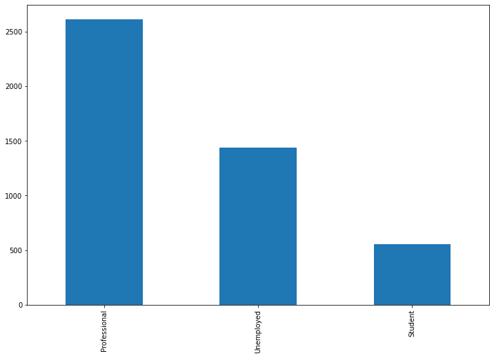

```python
data["current_occupation"].value_counts().plot.bar(figsize=(12,8))
plt.show()
```

We can see that we have huge number of customers with the current accupation as Professional

- Lets see how many customers are coming from mobile application and website

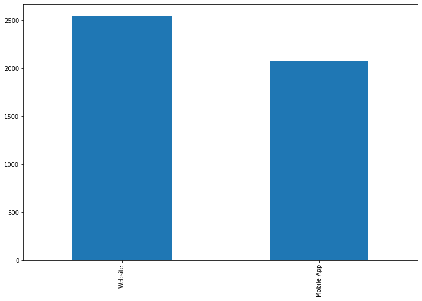

```python
data["first_interaction"].value_counts().plot.bar(figsize=(12,8))
plt.show()
```

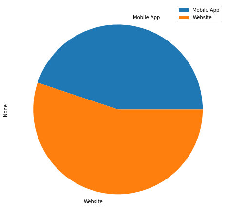

```python
data.groupby('first_interaction').size().plot(kind='pie', legend=True, figsize=(12,8))
```

We can see that the number of visitors from website are higher than mobile application

- Now lets see how many customers came through referral and how many are not

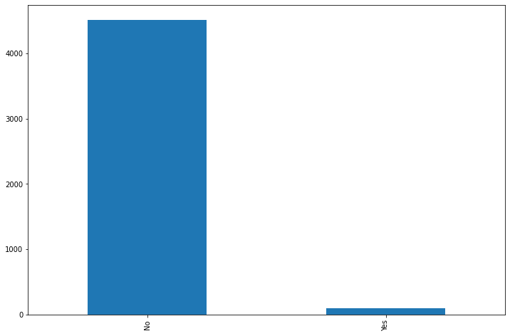

```python
data["referral"].value_counts().plot.bar(figsize=(12,8))
plt.show()
```

The above graph shows that only some customers came by referral link

- Lets check What percentage of profile has been filled by the lead on the website/mobile app.

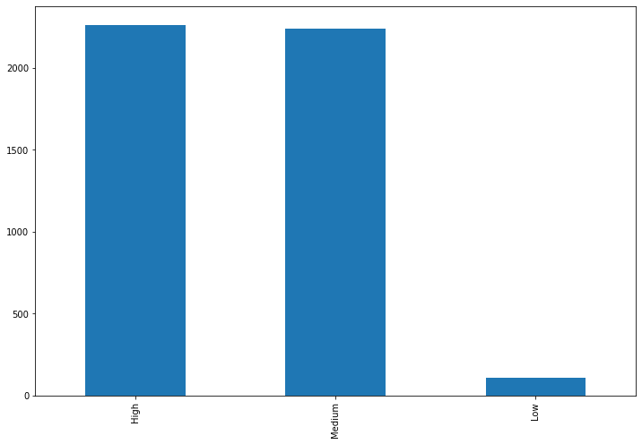

```python
data["profile_completed"].value_counts().plot.bar(figsize=(12,8))
plt.show()
```

- Lets check how many time a lead came back and visited again

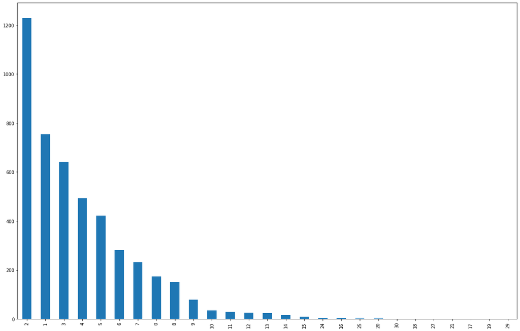

```python
data["website_visits"].value_counts().plot.bar(figsize=(20,13))
plt.show()
```

- Lets check the Last interaction between the lead and ExtraaLearn.

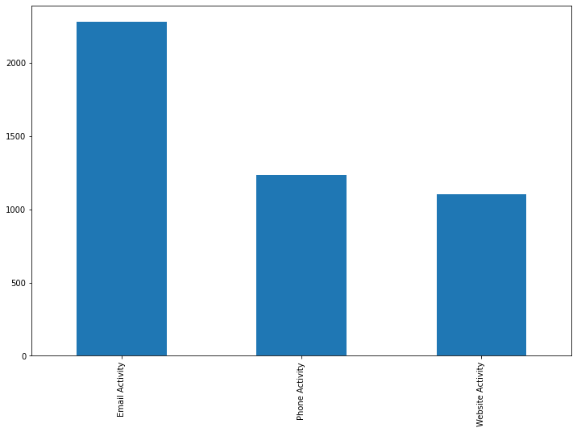

```python
data["last_activity"].value_counts().plot.bar(figsize=(12,8))
plt.show()
```

- Lets see whether the lead had seen the ad of ExtraaLearn in the Newspaper.

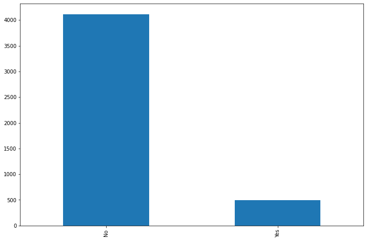

```python
data["print_media_type1"].value_counts().plot.bar(figsize=(12,8))
plt.show()
```

- Lets check whether the lead had seen the ad of ExtraaLearn in the Magazine.

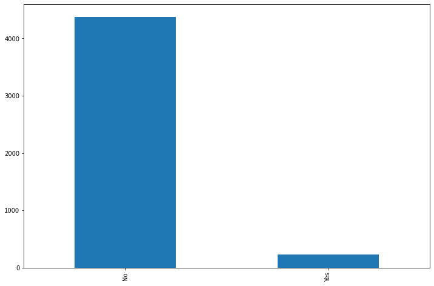

```python
data["print_media_type2"].value_counts().plot.bar(figsize=(12,8))
plt.show()
```

- Let see whether the lead had seen the ad of ExtraaLearn on the digital platforms.

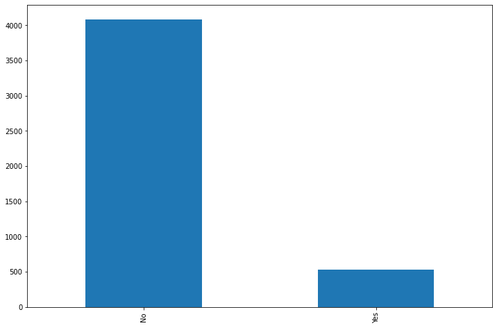

```python
data["digital_media"].value_counts().plot.bar(figsize=(12,8))
plt.show()
```

- Lets check whether the lead had heard about ExtraaLearn in the education channels like online forums, discussion threads, educational websites, etc.

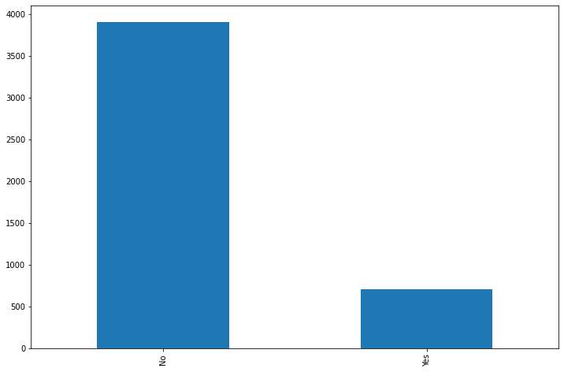

```python
data["educational_channels"].value_counts().plot.bar(figsize=(12,8))
plt.show()
```

- Lets check how many customers converted

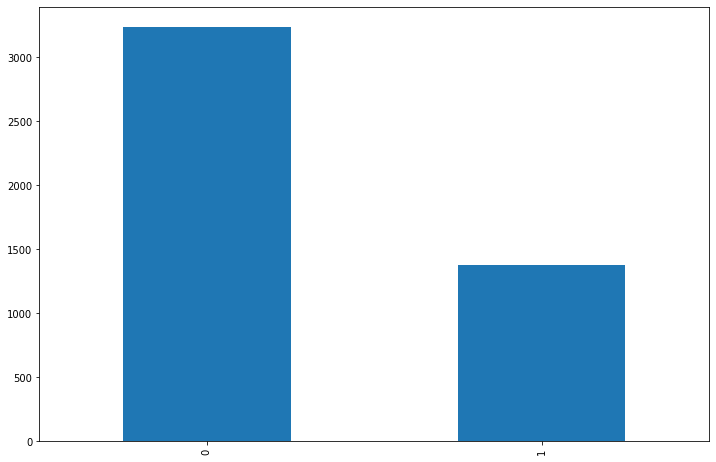

```python
data["status"].value_counts().plot.bar(figsize=(12,8))
plt.show()
```

We can see that small number of customers converted to real buyers

### 4. Data Cleaning

In this section, the data cleaning will be applied on the data to make it prepared for the machine learning

- In our dataset, we have categrocal columns which needs to be converted into numerical columns
- for example, "Current Occupation" have three categorical values, we will convert them into numerical values

```python
data.head()
```

|  | age | current_occupation | first_interaction | profile_completed | website_visits | time_spent_on_website | page_views_per_visit | last_activity | print_media_type1 | print_media_type2 | digital_media | educational_channels | referral | status |
| --- | --- | --- | --- | --- | --- | --- | --- | --- | --- | --- | --- | --- | --- | --- |
| 0 | 57 | Unemployed | Website | High | 7 | 1639 | 1.861 | Website Activity | Yes | No | Yes | No | No | 1 |
| 1 | 56 | Professional | Mobile App | Medium | 2 | 83 | 0.320 | Website Activity | No | No | No | Yes | No | 0 |
| 2 | 52 | Professional | Website | Medium | 3 | 330 | 0.074 | Website Activity | No | No | Yes | No | No | 0 |
| 3 | 53 | Unemployed | Website | High | 4 | 464 | 2.057 | Website Activity | No | No | No | No | No | 1 |
| 4 | 23 | Student | Website | High | 4 | 600 | 16.914 | Email Activity | No | No | No | No | No | 0 |

```python
data['current_occupation'].value_counts()
```

```
Professional    2616
Unemployed      1441
Student          555
Name: current_occupation, dtype: int64
```

As we can see that the current occupation feature have. we will convert this into numerical values and give specific number to each of the category, this is often called encoding

- Professional
- Unemployed
- Student

We will create a function for this

- the function will take the whole dataset
- take each categorical feature and convert it into numerical feature

```python
def encode(df):
    columnsToEncode = list(df.select_dtypes(include=['category','object']))
    le = LabelEncoder()
    for feature in columnsToEncode:
        try:
            df[feature] = le.fit_transform(df[feature])
        except:
            print('Error encoding '+feature)
    display(df)
```

```python
encode(data)
```

|  | age | current_occupation | first_interaction | profile_completed | website_visits | time_spent_on_website | page_views_per_visit | last_activity | print_media_type1 | print_media_type2 | digital_media | educational_channels | referral | status |
| --- | --- | --- | --- | --- | --- | --- | --- | --- | --- | --- | --- | --- | --- | --- |
| 0 | 57 | 2 | 1 | 0 | 7 | 1639 | 1.861 | 2 | 1 | 0 | 1 | 0 | 0 | 1 |
| 1 | 56 | 0 | 0 | 2 | 2 | 83 | 0.320 | 2 | 0 | 0 | 0 | 1 | 0 | 0 |
| 2 | 52 | 0 | 1 | 2 | 3 | 330 | 0.074 | 2 | 0 | 0 | 1 | 0 | 0 | 0 |
| 3 | 53 | 2 | 1 | 0 | 4 | 464 | 2.057 | 2 | 0 | 0 | 0 | 0 | 0 | 1 |
| 4 | 23 | 1 | 1 | 0 | 4 | 600 | 16.914 | 0 | 0 | 0 | 0 | 0 | 0 | 0 |
| ... | ... | ... | ... | ... | ... | ... | ... | ... | ... | ... | ... | ... | ... | ... |
| 4607 | 35 | 2 | 0 | 2 | 15 | 360 | 2.170 | 1 | 0 | 0 | 0 | 1 | 0 | 0 |
| 4608 | 55 | 0 | 0 | 2 | 8 | 2327 | 5.393 | 0 | 0 | 0 | 0 | 0 | 0 | 0 |
| 4609 | 58 | 0 | 1 | 0 | 2 | 212 | 2.692 | 0 | 0 | 0 | 0 | 0 | 0 | 1 |
| 4610 | 57 | 0 | 0 | 2 | 1 | 154 | 3.879 | 2 | 1 | 0 | 0 | 0 | 0 | 0 |
| 4611 | 55 | 0 | 1 | 2 | 4 | 2290 | 2.075 | 1 | 0 | 0 | 0 | 0 | 0 | 0 |

All the categorical features have been converted into numerical features

- lets check the correlation of the dataset

```python
cormat = data.corr()
round(cormat,2)
```

|  | age | current_occupation | first_interaction | profile_completed | website_visits | time_spent_on_website | page_views_per_visit | last_activity | print_media_type1 | print_media_type2 | digital_media | educational_channels | referral | status |
| --- | --- | --- | --- | --- | --- | --- | --- | --- | --- | --- | --- | --- | --- | --- |
| age | 1.00 | -0.05 | -0.00 | -0.00 | -0.01 | 0.02 | -0.04 | -0.01 | 0.01 | 0.01 | 0.02 | -0.02 | 0.00 | 0.12 |
| current_occupation | -0.05 | 1.00 | 0.01 | 0.00 | -0.01 | -0.00 | -0.00 | 0.01 | -0.01 | -0.02 | -0.02 | -0.02 | -0.02 | -0.10 |
| first_interaction | -0.00 | 0.01 | 1.00 | -0.00 | -0.05 | 0.00 | -0.01 | -0.00 | 0.01 | -0.01 | -0.01 | -0.02 | 0.02 | 0.38 |
| profile_completed | -0.00 | 0.00 | -0.00 | 1.00 | 0.01 | -0.03 | -0.00 | -0.02 | -0.00 | -0.00 | -0.01 | 0.01 | -0.04 | -0.25 |
| website_visits | -0.01 | -0.01 | -0.05 | 0.01 | 1.00 | 0.06 | 0.07 | 0.01 | -0.01 | 0.00 | -0.00 | 0.01 | 0.01 | -0.01 |
| ... | ... | ... | ... | ... | ... | ... | ... | ... | ... | ... | ... | ... | ... | ... |
| print_media_type2 | 0.01 | -0.02 | -0.01 | -0.00 | 0.00 | 0.02 | 0.01 | -0.00 | 0.02 | 1.00 | -0.00 | 0.02 | 0.01 | 0.01 |
| digital_media | 0.02 | -0.02 | -0.01 | -0.01 | -0.00 | 0.04 | 0.00 | -0.00 | 0.01 | -0.00 | 1.00 | 0.00 | 0.00 | 0.02 |
| educational_channels | -0.02 | -0.02 | -0.02 | 0.01 | 0.01 | -0.03 | 0.04 | 0.01 | 0.01 | 0.02 | 0.00 | 1.00 | 0.01 | -0.02 |
| referral | 0.00 | -0.02 | 0.02 | -0.04 | 0.01 | 0.06 | -0.00 | -0.01 | 0.00 | 0.01 | 0.00 | 0.01 | 1.00 | 0.12 |
| status | 0.12 | -0.10 | 0.38 | -0.25 | -0.01 | 0.30 | 0.00 | 0.05 | 0.02 | 0.01 | 0.02 | -0.02 | 0.12 | 1.00 |

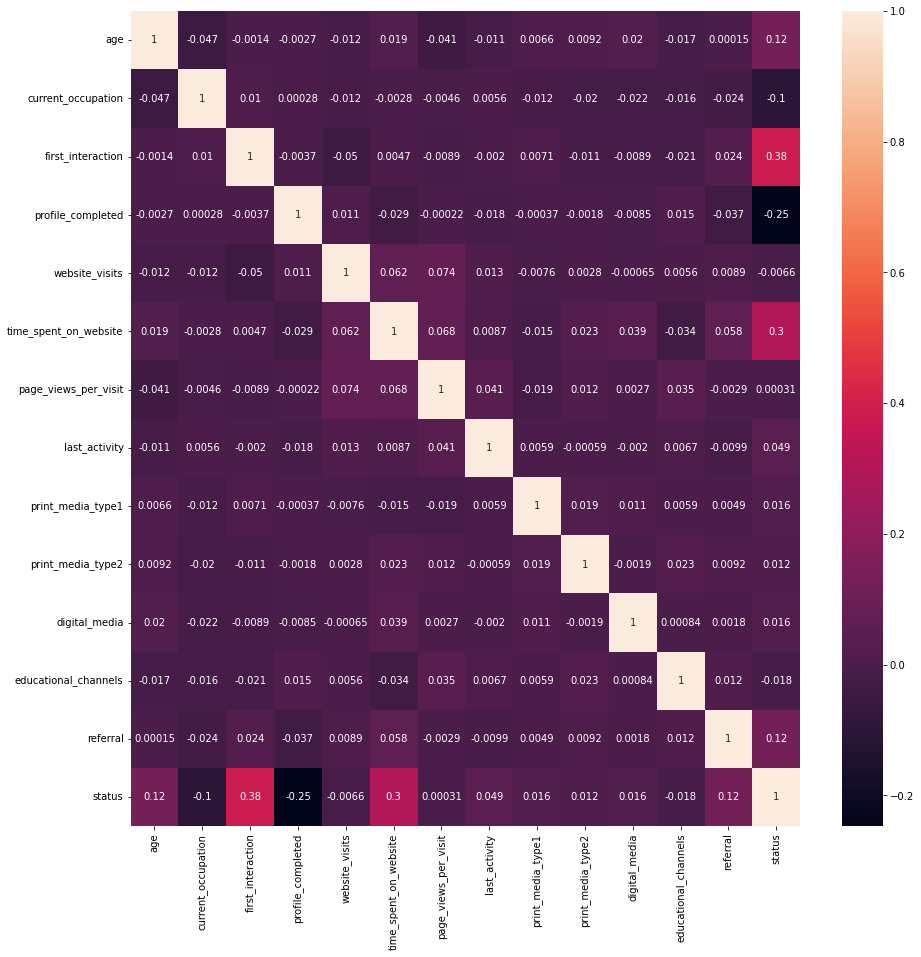

```python
plt.figure(figsize = (15,15))
sns.heatmap(cormat, annot = True)
```

The heatmap shows that the profile completed feature is negatively correlated with the status

- it means that if profile feature is increasing, the status will decrease and vice versa

### 5. Model Building

as we have explored the data and cleaned the data

- Now we will go ahead to split the data and train machine learning models
- We will train different models and based on the accuracy, we will select the model
- the selected model will go through hyperpatameter tuning at the end

```python
data['status'].value_counts()
```

```
0    3235
1    1377
Name: status, dtype: int64
```

Our dataset is highly imbalanced

#### 5.1. Data Splitting

```python
X = data.drop('status', axis = 1) # lets store all the independent features in X
```

```python
y = data['status'] # store the dependent variable in y
```

```python
X_train, X_test, y_train, y_test = train_test_split( X, y, test_size=0.2, random_state=42)
```

We have splitted the data into training and testing sets

- Training data will be used to train the models
- The testing data will be used to evaluate the model

#### 5.2. Logistic Regression

- Lets train the very first model on the data and see how it is performing

```python
logistic = LogisticRegression().fit(X_train, y_train)
```

```python
logistic.score(X_train,y_train)
```

```
0.7926267281105991
```

```python
logistic.score(X_test,y_test)
```

```
0.7800650054171181
```

Logistic Regression performed good, the accuracy on the testing and training data is good which means that our model is not overfitting the data, which is a good sign.

#### 5.3. Random Forest

lets try the Random Forest model

```python
random = RandomForestClassifier().fit(X_train, y_train)
```

```python
random.score(X_train,y_train)
```

```
0.9997289238275956
```

```python
random.score(X_test,y_test)
```

```
0.8483206933911159
```

The Random Forest gave accuracy greater than Logistic Regression

#### 5.4. Decision Tree

Lets move ahead and train the Decision Tree Classifier

```python
decision = DecisionTreeClassifier().fit(X_train, y_train)
```

```python
decision.score(X_train,y_train)
```

```
0.9997289238275956
```

```python
decision.score(X_test,y_test)
```

```
0.8320693391115926
```

The accuracy of Decision Tree on the testing data is lower than Random Forest

#### 5.5. Gradient Boosting

we will now train GradientBoostingClassifier

```python
gradient = GradientBoostingClassifier().fit(X_train, y_train)
```

```python
gradient.score(X_train,y_train)
```

```
0.8864190837625373
```

```python
gradient.score(X_test,y_test)
```

```
0.8732394366197183
```

Gradient Boosting classifier beats all the above model by giving the highest accuracy on testing data

#### 5.6. Extra Tree Classifier

```python
extra = ExtraTreesClassifier().fit(X_train, y_train)
```

```python
extra.score(X_train,y_train)
```

```
0.9997289238275956
```

```python
extra.score(X_test,y_test)
```

```
0.8374864572047671
```

We have trained 5 different machine learning cclassifiers. the highest accuracy is given by Gradient Boosting Classfier

- Lets train Gradient Boosting Classifier again using hyperparameter tuning
- with classification report and confusion metrix

## Gradient Boosting with parameters tuning

the highest accuracy is achieved by gradient boosting on testing data

- we will now train it again using different parameters using the GridSearchCv
- classification report
- confusion metrics

```python
# Here you will make the list of all possibilities for each of the Hyperparameters.
gbc = GradientBoostingClassifier()
parameters = {
    "n_estimators":[5,50,250,500],
    "max_depth":[1,3,5,7,9],
    "learning_rate":[0.01,0.1,1,10,100]
}
```

```python
# We are using the GrisSearchCV for cross validation
cv = GridSearchCV(gbc,parameters,cv=5)
cv.fit(X_train, y_train)
```

```
GridSearchCV(cv=5, estimator=GradientBoostingClassifier(),
             param_grid={'learning_rate': [0.01, 0.1, 1, 10, 100],
                         'max_depth': [1, 3, 5, 7, 9],
                         'n_estimators': [5, 50, 250, 500]})
```

```python
def display(results):
    print(f'Best parameters are: {results.best_params_}')
    print("\n")
    mean_score = results.cv_results_['mean_test_score']
    std_score = results.cv_results_['std_test_score']
    params = results.cv_results_['params']
    for mean,std,params in zip(mean_score,std_score,params):
        print(f'{round(mean,3)} + or -{round(std,3)} for the {params}')
```

```python
display(cv)
```

```
Best parameters are: {'learning_rate': 0.01, 'max_depth': 5, 'n_estimators': 250}


0.701 + or -0.001 for the {'learning_rate': 0.01, 'max_depth': 1, 'n_estimators': 5}
0.701 + or -0.001 for the {'learning_rate': 0.01, 'max_depth': 1, 'n_estimators': 50}
0.787 + or -0.009 for the {'learning_rate': 0.01, 'max_depth': 1, 'n_estimators': 250}
0.819 + or -0.01 for the {'learning_rate': 0.01, 'max_depth': 1, 'n_estimators': 500}
0.701 + or -0.001 for the {'learning_rate': 0.01, 'max_depth': 3, 'n_estimators': 5}
0.766 + or -0.01 for the {'learning_rate': 0.01, 'max_depth': 3, 'n_estimators': 50}
0.85 + or -0.02 for the {'learning_rate': 0.01, 'max_depth': 3, 'n_estimators': 250}
0.856 + or -0.018 for the {'learning_rate': 0.01, 'max_depth': 3, 'n_estimators': 500}
0.701 + or -0.001 for the {'learning_rate': 0.01, 'max_depth': 5, 'n_estimators': 5}
0.802 + or -0.015 for the {'learning_rate': 0.01, 'max_depth': 5, 'n_estimators': 50}
0.863 + or -0.015 for the {'learning_rate': 0.01, 'max_depth': 5, 'n_estimators': 250}
0.861 + or -0.013 for the {'learning_rate': 0.01, 'max_depth': 5, 'n_estimators': 500}
0.701 + or -0.001 for the {'learning_rate': 0.01, 'max_depth': 7, 'n_estimators': 5}
0.822 + or -0.009 for the {'learning_rate': 0.01, 'max_depth': 7, 'n_estimators': 50}
0.853 + or -0.014 for the {'learning_rate': 0.01, 'max_depth': 7, 'n_estimators': 250}
0.848 + or -0.013 for the {'learning_rate': 0.01, 'max_depth': 7, 'n_estimators': 500}
0.701 + or -0.001 for the {'learning_rate': 0.01, 'max_depth': 9, 'n_estimators': 5}
0.824 + or -0.008 for the {'learning_rate': 0.01, 'max_depth': 9, 'n_estimators': 50}
0.838 + or -0.009 for the {'learning_rate': 0.01, 'max_depth': 9, 'n_estimators': 250}
0.839 + or -0.008 for the {'learning_rate': 0.01, 'max_depth': 9, 'n_estimators': 500}
0.701 + or -0.001 for the {'learning_rate': 0.1, 'max_depth': 1, 'n_estimators': 5}
0.818 + or -0.014 for the {'learning_rate': 0.1, 'max_depth': 1, 'n_estimators': 50}
0.828 + or -0.013 for the {'learning_rate': 0.1, 'max_depth': 1, 'n_estimators': 250}
0.829 + or -0.009 for the {'learning_rate': 0.1, 'max_depth': 1, 'n_estimators': 500}
0.766 + or -0.009 for the {'learning_rate': 0.1, 'max_depth': 3, 'n_estimators': 5}
0.857 + or -0.016 for the {'learning_rate': 0.1, 'max_depth': 3, 'n_estimators': 50}
0.851 + or -0.015 for the {'learning_rate': 0.1, 'max_depth': 3, 'n_estimators': 250}
0.85 + or -0.016 for the {'learning_rate': 0.1, 'max_depth': 3, 'n_estimators': 500}
0.807 + or -0.005 for the {'learning_rate': 0.1, 'max_depth': 5, 'n_estimators': 5}
0.857 + or -0.013 for the {'learning_rate': 0.1, 'max_depth': 5, 'n_estimators': 50}
0.843 + or -0.009 for the {'learning_rate': 0.1, 'max_depth': 5, 'n_estimators': 250}
0.834 + or -0.006 for the {'learning_rate': 0.1, 'max_depth': 5, 'n_estimators': 500}
0.829 + or -0.009 for the {'learning_rate': 0.1, 'max_depth': 7, 'n_estimators': 5}
0.849 + or -0.008 for the {'learning_rate': 0.1, 'max_depth': 7, 'n_estimators': 50}
0.839 + or -0.013 for the {'learning_rate': 0.1, 'max_depth': 7, 'n_estimators': 250}
0.838 + or -0.013 for the {'learning_rate': 0.1, 'max_depth': 7, 'n_estimators': 500}
0.825 + or -0.006 for the {'learning_rate': 0.1, 'max_depth': 9, 'n_estimators': 5}
```

[output cut: 48 more lines]

```
0.369 + or -0.049 for the {'learning_rate': 100, 'max_depth': 3, 'n_estimators': 50}
0.369 + or -0.049 for the {'learning_rate': 100, 'max_depth': 3, 'n_estimators': 250}
0.369 + or -0.049 for the {'learning_rate': 100, 'max_depth': 3, 'n_estimators': 500}
0.481 + or -0.057 for the {'learning_rate': 100, 'max_depth': 5, 'n_estimators': 5}
0.481 + or -0.057 for the {'learning_rate': 100, 'max_depth': 5, 'n_estimators': 50}
0.48 + or -0.057 for the {'learning_rate': 100, 'max_depth': 5, 'n_estimators': 250}
0.48 + or -0.057 for the {'learning_rate': 100, 'max_depth': 5, 'n_estimators': 500}
0.522 + or -0.054 for the {'learning_rate': 100, 'max_depth': 7, 'n_estimators': 5}
0.461 + or -0.075 for the {'learning_rate': 100, 'max_depth': 7, 'n_estimators': 50}
0.5 + or -0.037 for the {'learning_rate': 100, 'max_depth': 7, 'n_estimators': 250}
0.53 + or -0.045 for the {'learning_rate': 100, 'max_depth': 7, 'n_estimators': 500}
0.609 + or -0.048 for the {'learning_rate': 100, 'max_depth': 9, 'n_estimators': 5}
0.613 + or -0.097 for the {'learning_rate': 100, 'max_depth': 9, 'n_estimators': 50}
0.67 + or -0.015 for the {'learning_rate': 100, 'max_depth': 9, 'n_estimators': 250}
0.634 + or -0.045 for the {'learning_rate': 100, 'max_depth': 9, 'n_estimators': 500}
```

So the best parameters are : {'learning_rate': 0.01, 'max_depth': 5, 'n_estimators': 250}

- we will train the model again on these parameters

```python
GradientBoosting = GradientBoostingClassifier(learning_rate=0.01, n_estimators=250, max_depth=5)
```

```python
GradientBoosting.fit(X_train, y_train)
```

```
GradientBoostingClassifier(learning_rate=0.01, max_depth=5, n_estimators=250)
```

```python
GradientBoosting.score(X_train,y_train)
```

```
0.8891298454865817
```

```python
GradientBoosting.score(X_test,y_test)
```

```
0.8764897074756229
```

```python
# Lets do the predictions on the testing data
pred = GradientBoosting.predict(X_test)
pred
```

```
array([0, 0, 0, 0, 0, 0, 0, 0, 0, 0, 0, 0, 1, 0, 0, 1, 1, 1, 0, 0, 0, 0,
       0, 0, 0, 0, 0, 0, 0, 1, 0, 0, 0, 0, 0, 1, 0, 0, 0, 1, 1, 0, 0, 0,
       0, 0, 0, 0, 0, 0, 1, 0, 1, 0, 0, 0, 0, 0, 0, 0, 1, 0, 0, 0, 1, 0,
       0, 0, 1, 0, 0, 1, 1, 0, 1, 0, 1, 0, 0, 1, 1, 0, 0, 0, 0, 0, 0, 0,
       0, 0, 0, 0, 1, 0, 0, 0, 1, 0, 0, 0, 0, 0, 0, 0, 1, 0, 1, 0, 0, 0,
       0, 0, 0, 0, 0, 0, 1, 1, 0, 0, 0, 0, 0, 0, 0, 0, 1, 0, 1, 0, 0, 0,
       0, 1, 1, 0, 0, 0, 1, 1, 0, 0, 0, 1, 0, 0, 1, 1, 0, 0, 1, 0, 0, 0,
       0, 0, 0, 1, 1, 0, 0, 0, 0, 0, 0, 1, 0, 0, 0, 1, 0, 1, 1, 0, 0, 0,
       1, 0, 0, 1, 0, 1, 0, 0, 1, 0, 0, 0, 0, 0, 0, 0, 0, 0, 0, 0, 1, 1,
       0, 0, 1, 0, 0, 1, 0, 0, 0, 0, 1, 1, 0, 0, 0, 0, 0, 1, 0, 0, 0, 0,
       0, 1, 0, 0, 0, 1, 0, 0, 1, 0, 0, 0, 0, 0, 0, 0, 0, 0, 0, 0, 0, 0,
       1, 0, 0, 1, 0, 0, 0, 1, 0, 0, 0, 0, 0, 1, 0, 0, 1, 0, 0, 0, 0, 0,
       0, 0, 0, 0, 0, 0, 0, 0, 1, 0, 0, 1, 0, 0, 1, 0, 0, 0, 0, 0, 0, 0,
       0, 0, 1, 1, 0, 0, 0, 1, 0, 0, 1, 0, 0, 1, 0, 0, 0, 1, 1, 0, 1, 0,
       0, 1, 0, 0, 0, 0, 0, 0, 0, 0, 0, 1, 0, 1, 1, 0, 0, 0, 0, 0, 0, 1,
```

[output cut: 28 more lines]

#### Classification Report & Confusion Metrics

```
              precision    recall  f1-score   support

           0       0.89      0.94      0.91       649
           1       0.83      0.74      0.78       274

    accuracy                           0.88       923
   macro avg       0.86      0.84      0.85       923
weighted avg       0.87      0.88      0.87       923
```

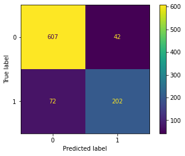

```python
print(classification_report(y_test, pred))
plot_confusion_matrix(GradientBoosting, X_test, y_test)
plt.show()
```